# The R Ecosystem

Pier Lorenzo Paracchini  
20.09.2017

### The R Ecosystem: an overview

[figure not shown]

### The R environment

The R environment is divided in 2 different conceptual parts:

- the *“base”* R system, what is installed when installing R from **CRAN**, and
- everything else.

The *“base”* R system contains the core functionality required to run R

- the `base` package, and
- other packages like `utils, stats, datasets, graphics, grDevices, grid, methods, tools, parallel, compiler, splines, tcltk, stats4`

More functionality can be added to the R environment installing more packages.

### What is a package?

A **package** is essentially

- a **library** designed to accomplish a task or a set of tasks. E.g.
  - the `tidyr` package provides functionality for data tidying,
  - the `ggplot2` package provides functionality for plotting and visualization, …

Packages can be found in the following repositories

- Comprehensive R Archive Network ([CRAN](https://cran.r-project.org/))
- [BioConductor](http://bioconductor.org/)
- GitHub/ BitBucket reposotories (an example tidyr)

### Package lifecycle

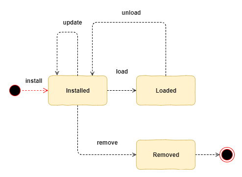

- **Install**/ **update** a package
- **Load**/ **unload** a package
- **Remove** a package

### Package lifecycle: install a package

From CRAN/ local file

```r
# Installing new packages
## Use the RSTUDIO IDE:
#    Tools->Install Packages...

## Use command line
install..packages("...")
```

From GitHub/ BitBucket

```r
# Installing new packages

require(devtools)
install_github(repo = "", username = "...")

# Note! Sometime the repository contains source code
# then the proper compilers must be installed.
```

### Package lifecycle: update a package

From time to time packages must be updated…

```r
# list all packages where an update is available
old.packages()

# update all available packages
update.packages()

# update, without prompts for permission/clarification
update.packages(ask = FALSE)

# update only a specific package use install.packages()
install.packages("plotly")
```

### Package Management: load/ unload a package

A package needs to be **loaded** (only once) in a R session in order to be used

```r
# Loading a package
#   resilient: return TRUE if done, otherwise FALSE
require(packageName)

#   throw an error if not done
library(packageName)

#   load the required function in the package
packageName::function
```

To **unload** the package from the current R session

```r
# unloading a package
detach("package:packageName")
```

### Package lifecycle: remove a package

```r
## Use the RSTUDIO IDE - Packages tab

## Command line
remove.packages(...)
```

### Getting Help

There are many resources on the Internet and, because of its single-letter name, R is difficult to search for using general-purpose search engines such as Google.

- **Searching for more information and help**
  - The Comprehensive R Archive Network (CRAN) at http://cran.r-project.org/
  - The R Project home page, http://www.r-project.org/
    - See **Manuals** section.
    - See **Search** section.
  - Stack Overflow
- **Asking for help**
  - R email lists at http://www.r-project.org/mail.html.

### Getting Help (Cont'd)

**The `help` function** can be used to get online help.

```r
# We want to get some more information about the args function
help(args)

# a shortcut...
?args

# working with special characters
?"+"
?"for"
```

**The `example` function** can be used to run examples provided in the help entries.

```r
# In most of the online help pages there is an Examples section
# with some examples on how to use what we have been searching for
# some examples can be run using the example function

example(args)

# Another example
# 'persp' draws perspective plots of a surface over the x–y plane

example(persp)
```

### Getting Help (Cont'd)

If you do not know exactly what you are looking for `help.search` can be used to perform a Google-style search through R documentation.

```r
help.search("multivariate normal")

# shortcut
??"multivariate normal"
```

If you want to access information related to a specific package…

```r
help(package=dplyr)
```

Some other topics…

```r
?files
?Arithmetic

# Arithmetic, Comparison, Control, Dates, Extract, files, Math, Memory, NA
# NULL, NumericaConstants, Paren, Quotes, Startup, Syntax
```

The [`sos`](https://cran.r-project.org/web/packages/sos/index.html) package offers highly sophisticated searching of R materials (instaled packages).